# Omp-tTA X tetO-Tet3 ribominus-RNA analysis

```r
opts_knit$set(verbose = T)
library(reshape2)
library(plyr)
suppressPackageStartupMessages(source("~/src/seqAnalysis/R/features.R"))
```

Extract FPKM values from Cuffdiff output

```
cd <- read.delim("~/s2/data/rna/cuffdiff/omp_ott3_rmrna_rep12_masked_uq_comp_js/gene_exp.diff")
rna <- cd[,c("value_1", "value_2")]
```

Average entries with common gene names

```
library(plyr)
rna[,3] <- cd$gene
colnames(rna) <- c("omp", "ott3", "gene")
rna.s <- ddply(rna, .(gene), summarize, omp=mean(omp), ott3=mean(ott3), .progress="text")
rownames(rna.s) <- rna.s$gene
rna.s <- rna.s[,c(2,3)]
rna.1log2 <- colwise(function(x) log2(x+1))(rna.s)
rownames(rna.1log2) <- rownames(rna.s)
rna.1log2$ott3.omp <- with(rna.1log2, ott3-omp)
saveRDS(rna.1log2, file="~/s2/analysis/rna/rdata/omp_ott3_rmrna_rep12_masked_comp_js_1log2.rds")
```

```r
rna.1log2 <- readRDS("~/s2/analysis/rna/rdata/omp_ott3_rmrna_rep12_masked_comp_js_1log2.rds")
```

Scatter OMP and O/TT3 log2(FPKM+1).

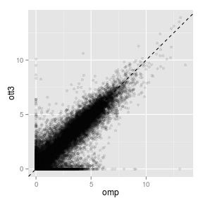

```r
library(ggplot2)
gg <- ggplot(rna.1log2, aes(omp, ott3))
gg + geom_point(alpha = I(1/10)) + geom_abline(slope = 1, intercept = 0, linetype = 2)
```

Scatter replicates

```r
rna <- read.delim("~/s2/data/rna/cuffdiff/omp_ott3_rmrna_rep12_masked_uq_comp_js/genes.read_group_tracking")
rna.fpkm <- dcast(rna, tracking_id ~ condition + replicate, value.var = "FPKM")
rna.fpkm.1log2 <- numcolwise(onelog2)(rna.fpkm)
cor(rna.fpkm.1log2)
```

```
##        q1_0   q1_1   q2_0   q2_1
## q1_0 1.0000 0.9166 0.8963 0.8606
## q1_1 0.9166 1.0000 0.8661 0.9297
## q2_0 0.8963 0.8661 1.0000 0.9049
## q2_1 0.8606 0.9297 0.9049 1.0000
```

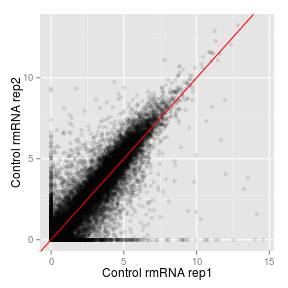

```r
gg <- ggplot(rna.fpkm.1log2, aes(q1_0, q1_1))
gg <- gg + geom_point(alpha = I(1/10)) + geom_abline(slope = 1, intercept = 0,
    color = 2)
gg <- gg + labs(x = "Control rmRNA rep1", y = "Control rmRNA rep2")
gg
```

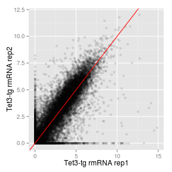

```r
gg <- ggplot(rna.fpkm.1log2, aes(q2_0, q2_1))
gg <- gg + geom_point(alpha = I(1/10)) + geom_abline(slope = 1, intercept = 0,
    color = 2)
gg <- gg + labs(x = "Tet3-tg rmRNA rep1", y = "Tet3-tg rmRNA rep2")
gg
```

### 5hmC heatmaps

Load omp, o/tt3 hmc gene position matrices

```r
suppressPackageStartupMessages(source("~/src/seqAnalysis/R/image.R"))
omp.hmc.pos <- makeImage("omp_hmc_dampen5", "gene_whole_W200N50F50_chr", data_type = "rpkm_rep/mean",
    image = FALSE)
```

```
## [1] "/media/storage2/analysis/profiles/norm/rpkm_rep/mean/gene_whole_W200N50F50_chr/images/omp_hmc_dampen5"
```

```r
ott3.hmc.pos <- makeImage("ott3_hmc_dampen5", "gene_whole_W200N50F50_chr", data_type = "rpkm_rep/mean",
    image = FALSE)
```

```
## [1] "/media/storage2/analysis/profiles/norm/rpkm_rep/mean/gene_whole_W200N50F50_chr/images/ott3_hmc_dampen5"
```

```r
ott3.omp.hmc.pos <- ott3.hmc.pos - omp.hmc.pos
```

Principal components analysis on gene body to order

```r
omp.hmc.pos.pc <- prcomp(omp.hmc.pos[, 51:100])
ott3.hmc.pos.pc <- prcomp(ott3.hmc.pos[, 51:100])
omp.hmc.pos.pred <- predict(omp.hmc.pos.pc, omp.hmc.pos[, 51:100])
ott3.hmc.pos.pred <- predict(ott3.hmc.pos.pc, ott3.hmc.pos[, 51:100])

omp.hmc.pos.pc1 <- omp.hmc.pos[match(rownames(omp.hmc.pos.pred[order(omp.hmc.pos.pred[,
    1]), ]), rownames(omp.hmc.pos)), ]
ott3.hmc.pos.pc1 <- ott3.hmc.pos[match(rownames(ott3.hmc.pos.pred[order(ott3.hmc.pos.pred[,
    1]), ]), rownames(ott3.hmc.pos)), ]
omp.hmc.pos.ott3.pc1 <- omp.hmc.pos[match(rownames(ott3.hmc.pos.pred[order(ott3.hmc.pos.pred[,
    1]), ]), rownames(omp.hmc.pos)), ]
ott3.hmc.pos.omp.pc1 <- ott3.hmc.pos[match(rownames(omp.hmc.pos.pred[order(omp.hmc.pos.pred[,
    1]), ]), rownames(ott3.hmc.pos)), ]

omp.hmc.pos.pc2 <- omp.hmc.pos[match(rownames(omp.hmc.pos.pred[order(omp.hmc.pos.pred[,
    2]), ]), rownames(omp.hmc.pos)), ]
ott3.hmc.pos.pc2 <- ott3.hmc.pos[match(rownames(ott3.hmc.pos.pred[order(ott3.hmc.pos.pred[,
    2]), ]), rownames(ott3.hmc.pos)), ]
omp.hmc.pos.ott3.pc2 <- omp.hmc.pos[match(rownames(ott3.hmc.pos.pred[order(ott3.hmc.pos.pred[,
    2]), ]), rownames(omp.hmc.pos)), ]
ott3.hmc.pos.omp.pc2 <- ott3.hmc.pos[match(rownames(omp.hmc.pos.pred[order(omp.hmc.pos.pred[,
    2]), ]), rownames(ott3.hmc.pos)), ]
```

Order difference matrix

```r
ott3.omp.hmc.pos.omp.pc1 <- na.omit(ott3.omp.hmc.pos[match(rownames(omp.hmc.pos.pc1),
    rownames(ott3.omp.hmc.pos)), ])
ott3.omp.hmc.pos.ott3.pc1 <- na.omit(ott3.omp.hmc.pos[match(rownames(ott3.hmc.pos.pc1),
    rownames(ott3.omp.hmc.pos)), ])
```

Compare orders with RNA

```r
rna.1log2.omp.pc1 <- na.omit(rna.1log2[match(rownames(omp.hmc.pos.pc1), rownames(rna.1log2)),
    ])
rna.1log2.ott3.pc1 <- na.omit(rna.1log2[match(rownames(ott3.hmc.pos.pc1), rownames(rna.1log2)),
    ])
```

Group in 100 chunks

```r
source("~/src/seqAnalysis/R/boot.R")
ott3.omp.hmc.pos.omp.pc1.c100 <- foreach(c = isplitRows(ott3.omp.hmc.pos.omp.pc1[,
    51:100], chunks = 100), .combine = "rbind") %do% mean(c, na.rm = TRUE)
ott3.omp.hmc.pos.omp.pc1.c100 <- as.data.frame(ott3.omp.hmc.pos.omp.pc1.c100)
ott3.omp.hmc.pos.omp.pc1.c100$index <- 100:1
ott3.omp.hmc.pos.omp.pc1.c100.boot <- foreach(c = isplitRows(ott3.omp.hmc.pos.omp.pc1[,
    51:100], chunks = 100), .combine = "rbind") %do% bootCI(apply(c, 1, mean))
ott3.omp.hmc.pos.omp.pc1.c100 <- cbind(ott3.omp.hmc.pos.omp.pc1.c100, ott3.omp.hmc.pos.omp.pc1.c100.boot)
colnames(ott3.omp.hmc.pos.omp.pc1.c100)[3:4] <- c("ott3.omp.lower", "ott3.omp.upper")

ott3.omp.hmc.pos.ott3.pc1.c100 <- foreach(c = isplitRows(ott3.omp.hmc.pos.ott3.pc1[,
    51:100], chunks = 100), .combine = "rbind") %do% mean(c, na.rm = TRUE)
ott3.omp.hmc.pos.ott3.pc1.c100 <- as.data.frame(ott3.omp.hmc.pos.ott3.pc1.c100)
ott3.omp.hmc.pos.ott3.pc1.c100$index <- 100:1
ott3.omp.hmc.pos.ott3.pc1.c100.boot <- foreach(c = isplitRows(ott3.omp.hmc.pos.ott3.pc1[,
    51:100], chunks = 100), .combine = "rbind") %do% bootCI(apply(c, 1, mean))
ott3.omp.hmc.pos.ott3.pc1.c100 <- cbind(ott3.omp.hmc.pos.ott3.pc1.c100, ott3.omp.hmc.pos.ott3.pc1.c100.boot)
colnames(ott3.omp.hmc.pos.ott3.pc1.c100)[3:4] <- c("ott3.omp.lower", "ott3.omp.upper")

rna.1log2.omp.pc1.c100 <- foreach(c = isplitRows(rna.1log2.omp.pc1[, c(1:3)],
    chunks = 100), .combine = "rbind") %do% apply(c, 2, mean, na.rm = TRUE)
rna.1log2.omp.pc1.c100 <- as.data.frame(rna.1log2.omp.pc1.c100)
rna.1log2.omp.pc1.c100$index <- 100:1
rna.1log2.omp.pc1.c100.boot <- foreach(c = isplitRows(rna.1log2.omp.pc1[, c(1:3)],
    chunks = 100), .combine = "rbind") %do% apply(c, 2, bootCI)
rna.1log2.omp.pc1.c100 <- cbind(rna.1log2.omp.pc1.c100, rna.1log2.omp.pc1.c100.boot[seq(1,
    nrow(rna.1log2.omp.pc1.c100.boot), 2), ], rna.1log2.omp.pc1.c100.boot[seq(2,
    nrow(rna.1log2.omp.pc1.c100.boot), 2), ])
colnames(rna.1log2.omp.pc1.c100)[5:10] <- c("omp.lower", "ott3.lower", "ott3.omp.lower",
    "omp.upper", "ott3.upper", "ott3.omp.upper")

rna.1log2.ott3.pc1.c100 <- foreach(c = isplitRows(rna.1log2.ott3.pc1[, c(1:3)],
    chunks = 100), .combine = "rbind") %do% apply(c, 2, mean, na.rm = TRUE)
rna.1log2.ott3.pc1.c100 <- as.data.frame(rna.1log2.ott3.pc1.c100)
rna.1log2.ott3.pc1.c100$index <- 100:1
rna.1log2.ott3.pc1.c100.boot <- foreach(c = isplitRows(rna.1log2.ott3.pc1[,
    c(1:3)], chunks = 100), .combine = "rbind") %do% apply(c, 2, bootCI)
rna.1log2.ott3.pc1.c100 <- cbind(rna.1log2.ott3.pc1.c100, rna.1log2.ott3.pc1.c100.boot[seq(1,
    nrow(rna.1log2.ott3.pc1.c100.boot), 2), ], rna.1log2.ott3.pc1.c100.boot[seq(2,
    nrow(rna.1log2.ott3.pc1.c100.boot), 2), ])
colnames(rna.1log2.ott3.pc1.c100)[5:10] <- c("omp.lower", "ott3.lower", "ott3.omp.lower",
    "omp.upper", "ott3.upper", "ott3.omp.upper")
```

```r
rna.1log2.omp.pc1.c100$wilcox.FDR <- p.adjust(foreach(c = isplitRows(rna.1log2.omp.pc1[,
    1:3], chunks = 100), .combine = "rbind") %do% wilcox.test(c[, 3])$p.value,
    method = "fdr")
rna.1log2.omp.pc1.c100$wilcox.FDR.05 <- cut(rna.1log2.omp.pc1.c100$wilcox.FDR,
    breaks = c(0, 0.05, 1))
rna.1log2.ott3.pc1.c100$wilcox.FDR <- p.adjust(foreach(c = isplitRows(rna.1log2.ott3.pc1[,
    1:3], chunks = 100), .combine = "rbind") %do% wilcox.test(c[, 3])$p.value,
    method = "fdr")
rna.1log2.ott3.pc1.c100$wilcox.FDR.05 <- cut(rna.1log2.ott3.pc1.c100$wilcox.FDR,
    breaks = c(0, 0.05, 1))
```

#### Plot heatmaps - PC1

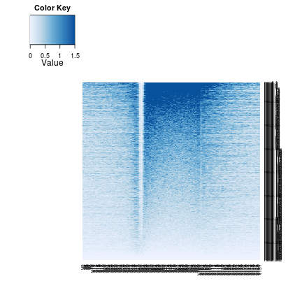

```r
MP.heat(omp.hmc.pos.pc1, range = c(0, 1.5), average = 50)
```

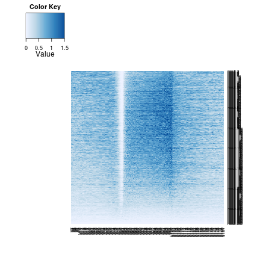

```r
MP.heat(ott3.hmc.pos.omp.pc1, range = c(0, 1.5), average = 50)
```

O/TT3 - OMP gene body 5hmC ordered by OMP 5hmC PC1

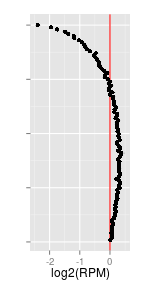

```r
gg <- ggplot(ott3.omp.hmc.pos.omp.pc1.c100, aes(V1, index))
gg <- gg + geom_vline(xintercept = 0, color = "red")
gg <- gg + geom_point(size = 2) + xlab("log2(RPM)") + ylab("") + theme(legend.position = "none",
    axis.text.y = element_blank()) + geom_errorbarh(aes(xmin = ott3.omp.lower,
    xmax = ott3.omp.upper), height = 0, size = 0.1)
gg
```

```r
# gg + geom_point() + xlab('RPM') + ylab('') +
# theme(axis.text.y=element_blank()) + coord_cartesian(xlim=c(-2, .5))
```

OMP rmRNA ordered by OMP 5hmC PC1

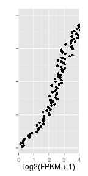

```r
gg <- ggplot(rna.1log2.omp.pc1.c100, aes(omp, index))
gg + geom_point() + xlab("log2(FPKM + 1)") + ylab("") + theme(axis.text.y = element_blank()) +
    coord_cartesian(xlim = c(0, 4))
```

O/TT3 rmRNA ordered by OMP 5hmC PC1

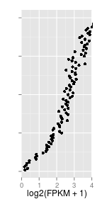

```r
gg <- ggplot(rna.1log2.omp.pc1.c100, aes(ott3, index))
gg <- gg + geom_point() + xlab("log2(FPKM + 1)") + ylab("") + theme(axis.text.y = element_blank()) +
    coord_cartesian(xlim = c(0, 4))
gg
```

O/TT3 - OMP rmRNA ratio ordered by OMP 5hmC PC1

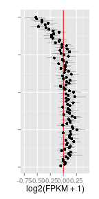

```r
theme_set(theme_gray())
gg <- ggplot(as.data.frame(rna.1log2.omp.pc1.c100), aes(ott3.omp, index))
gg <- gg + geom_vline(xintercept = 0, color = "red")
gg <- gg + geom_point(size = 2) + xlab("log2(FPKM + 1)") + ylab("") + theme(legend.position = "none",
    axis.text.y = element_blank()) + geom_errorbarh(aes(xmin = ott3.omp.lower,
    xmax = ott3.omp.upper), height = 0, size = 0.1)
gg
```

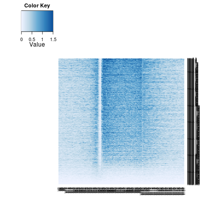

```r
MP.heat(omp.hmc.pos.ott3.pc1, range = c(0, 1.5), average = 50)
```

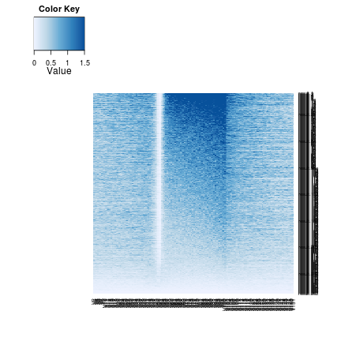

```r
MP.heat(ott3.hmc.pos.pc1, range = c(0, 1.5), average = 50)
```

O/TT3 - OMP gene body 5hmC ordered by O/TT3 5hmC PC1

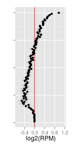

```r
gg <- ggplot(ott3.omp.hmc.pos.ott3.pc1.c100, aes(V1, index))
gg <- gg + geom_vline(xintercept = 0, color = "red")
gg <- gg + geom_point(size = 2) + xlab("log2(RPM)") + ylab("") + theme(legend.position = "none",
    axis.text.y = element_blank()) + geom_errorbarh(aes(xmin = ott3.omp.lower,
    xmax = ott3.omp.upper), height = 0, size = 0.1)
gg
```

```r
# gg + geom_point() + xlab('RPM') + ylab('') +
# theme(axis.text.y=element_blank()) + coord_cartesian(xlim=c(-.5, 1))
```

OMP rmRNA ordered by O/TT3 5hmC PC1

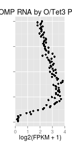

```r
gg <- ggplot(rna.1log2.ott3.pc1.c100, aes(omp, index))
gg + geom_point() + xlab("log2(FPKM + 1)") + ylab("") + theme(axis.text.y = element_blank()) +
    coord_cartesian(xlim = c(0, 4)) + labs(title = c("OMP RNA by O/Tet3 PC1"))
```

O/TT3 rmRNA ordered by O/TT3 5hmC PC1

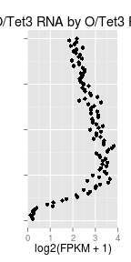

```r
gg <- ggplot(rna.1log2.ott3.pc1.c100, aes(ott3, index))
gg + geom_point() + xlab("log2(FPKM + 1)") + ylab("") + theme(axis.text.y = element_blank()) +
    coord_cartesian(xlim = c(0, 4)) + labs(title = c("O/Tet3 RNA by O/Tet3 PC1"))
```

Plot O/TT3 - OMP rmRNA ratio ordered by O/TT3 5hmC PC1

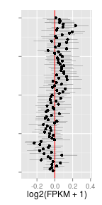

```r
gg <- ggplot(rna.1log2.ott3.pc1.c100, aes(ott3.omp, index))
gg <- gg + geom_vline(xintercept = 0, color = "red")
gg <- gg + geom_point(size = 2) + xlab("log2(FPKM + 1)") + ylab("") + theme(legend.position = "none",
    axis.text.y = element_blank()) + geom_errorbarh(aes(xmin = ott3.omp.lower,
    xmax = ott3.omp.upper), height = 0, size = 0.1)
gg
```

#### Prep RNA - PC2

```r
rna.1log2.omp.pc2 <- na.omit(rna.1log2[match(rownames(omp.hmc.pos.pc2), rownames(rna.1log2)),
    ])
rna.1log2.ott3.pc2 <- na.omit(rna.1log2[match(rownames(ott3.hmc.pos.pc2), rownames(rna.1log2)),
    ])
rna.1log2.omp.pc2.c100 <- foreach(c = isplitRows(rna.1log2.omp.pc2[, c(1:3)],
    chunks = 100), .combine = "rbind") %do% apply(c, 2, mean, na.rm = TRUE)
rna.1log2.omp.pc2.c100 <- as.data.frame(rna.1log2.omp.pc2.c100)
rna.1log2.omp.pc2.c100$index <- 100:1
rna.1log2.omp.pc2.c100.boot <- foreach(c = isplitRows(rna.1log2.omp.pc2[, c(1:3)],
    chunks = 100), .combine = "rbind") %do% apply(c, 2, bootCI)
rna.1log2.omp.pc2.c100 <- cbind(rna.1log2.omp.pc2.c100, rna.1log2.omp.pc2.c100.boot[seq(1,
    nrow(rna.1log2.omp.pc2.c100.boot), 2), ], rna.1log2.omp.pc2.c100.boot[seq(2,
    nrow(rna.1log2.omp.pc2.c100.boot), 2), ])
colnames(rna.1log2.omp.pc2.c100)[5:10] <- c("omp.lower", "ott3.lower", "ott3.omp.lower",
    "omp.upper", "ott3.upper", "ott3.omp.upper")

rna.1log2.ott3.pc2.c100 <- foreach(c = isplitRows(rna.1log2.ott3.pc2[, c(1:3)],
    chunks = 100), .combine = "rbind") %do% apply(c, 2, mean, na.rm = TRUE)
rna.1log2.ott3.pc2.c100 <- as.data.frame(rna.1log2.ott3.pc2.c100)
rna.1log2.ott3.pc2.c100$index <- 100:1
rna.1log2.ott3.pc2.c100.boot <- foreach(c = isplitRows(rna.1log2.ott3.pc2[,
    c(1:3)], chunks = 100), .combine = "rbind") %do% apply(c, 2, bootCI)
rna.1log2.ott3.pc2.c100 <- cbind(rna.1log2.ott3.pc2.c100, rna.1log2.ott3.pc2.c100.boot[seq(1,
    nrow(rna.1log2.ott3.pc2.c100.boot), 2), ], rna.1log2.ott3.pc2.c100.boot[seq(2,
    nrow(rna.1log2.ott3.pc2.c100.boot), 2), ])
colnames(rna.1log2.ott3.pc2.c100)[5:10] <- c("omp.lower", "ott3.lower", "ott3.omp.lower",
    "omp.upper", "ott3.upper", "ott3.omp.upper")
```

#### Plot heatmaps - PC2

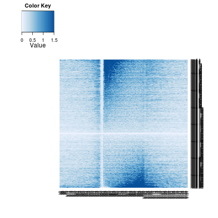

```r
MP.heat(omp.hmc.pos.pc2, range = c(0, 1.5), average = 50)
```

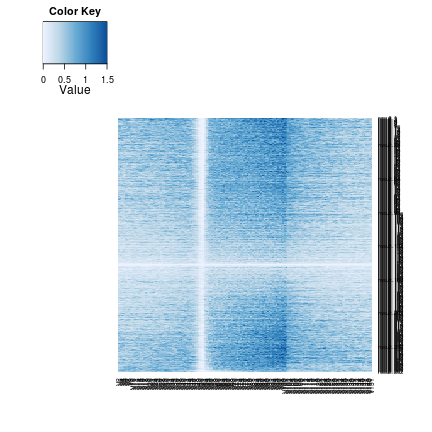

```r
MP.heat(ott3.hmc.pos.omp.pc2, range = c(0, 1.5), average = 50)
```

```r
gg <- ggplot(ott3.omp.hmc.pos.omp.pc2.c100, aes(V1, index))
```

```
## Error: object 'ott3.omp.hmc.pos.omp.pc2.c100' not found
```

[figure not shown]

```r
gg + geom_point() + xlab("RPM") + ylab("") + theme(axis.text.y = element_blank()) +
    coord_cartesian(xlim = c(-2, 0.5))
```

OMP rmRNA ordered by OMP 5hmC pc2

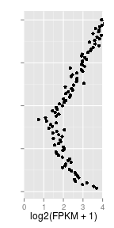

```r
gg <- ggplot(rna.1log2.omp.pc2.c100, aes(omp, index))
gg + geom_point() + xlab("log2(FPKM + 1)") + ylab("") + theme(axis.text.y = element_blank()) +
    coord_cartesian(xlim = c(0, 4))
```

O/TT3 rmRNA ordered by OMP 5hmC pc2

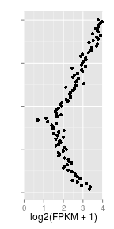

```r
gg <- ggplot(rna.1log2.omp.pc2.c100, aes(ott3, index))
gg <- gg + geom_point() + xlab("log2(FPKM + 1)") + ylab("") + theme(axis.text.y = element_blank()) +
    coord_cartesian(xlim = c(0, 4))
gg
```

[output not shown]

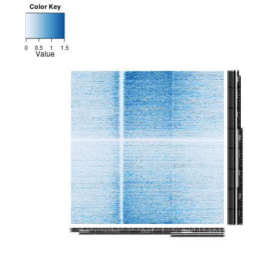

```r
MP.heat(omp.hmc.pos.ott3.pc2, range = c(0, 1.5), average = 50)
```

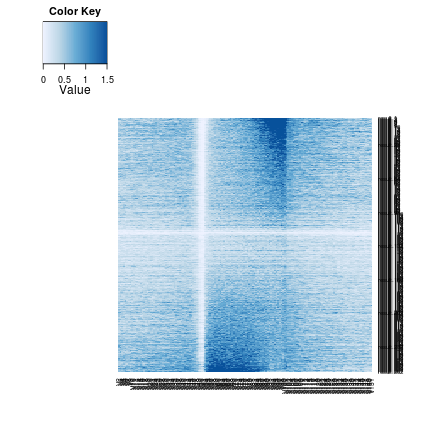

```r
MP.heat(ott3.hmc.pos.pc2, range = c(0, 1.5), average = 50)
```

```r
gg <- ggplot(ott3.omp.hmc.pos.ott3.pc2.c100, aes(V1, index))
```

```
## Error: object 'ott3.omp.hmc.pos.ott3.pc2.c100' not found
```

[figure not shown]

```r
gg + geom_point() + xlab("RPM") + ylab("") + theme(axis.text.y = element_blank()) +
    coord_cartesian(xlim = c(-0.5, 1))
```

OMP rmRNA ordered by O/TT3 5hmC pc2

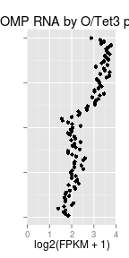

```r
gg <- ggplot(rna.1log2.ott3.pc2.c100, aes(omp, index))
gg + geom_point() + xlab("log2(FPKM + 1)") + ylab("") + theme(axis.text.y = element_blank()) +
    coord_cartesian(xlim = c(0, 4)) + labs(title = c("OMP RNA by O/Tet3 pc2"))
```

O/TT3 rmRNA ordered by O/TT3 5hmC pc2

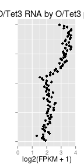

```r
gg <- ggplot(rna.1log2.ott3.pc2.c100, aes(ott3, index))
gg + geom_point() + xlab("log2(FPKM + 1)") + ylab("") + theme(axis.text.y = element_blank()) +
    coord_cartesian(xlim = c(0, 4)) + labs(title = c("O/Tet3 RNA by O/Tet3 pc2"))
```

[output not shown]